# Prediction using GFBLUP and cross validation

Izel Fourie Sørensen

15 November, 2018

Here we show how to perform a Genomic Feature Best Linear Unbiased Prediction (GFBLUP) analyses and cross validation using the `greml` function in **qgg**. The GFBLUP model includes an additional genomic effect that quantifies the collective action of a set of markers, i.e. a genomic feature. In this example, the markers associated with a chromosome are considered as a feature (set of markers). Performing GFBLUP involves estimating variance components for each of the feature sets with REstricted Maximum Likelihood estimation (REML). The ability of the GFBLUP model to predict the phenotype is assessed using a cross validation procedure. This will be illustrated on the “starvation resistance” phenotype and genotype data available from the [*Drosophila* genetic reference panel](http://dgrp2.gnets.ncsu.edu/) (DGRP).

To perform a GFBLUP analysis the following input data is essential.

1. $\mathbf{y}$: vector of phenotype
2. $\mathbf{X}$: design matrix for covariables
3. Genomic feature marker sets
4. $\mathbf{W}$: centered and scaled genotype matrix
5. $\mathbf{G}$: genomic relationship matrix for each feature

This script includes the following steps: 1) load and prepare data, 2) restricted maximum likelihood (REML) analyses for estimating variance components, and 3) REML analyses and cross validation using the GFBLUP model.

```r
#library(devtools)
#install_github("psoerensen/qgg")
library(qgg)
```

#### **Load and prepare data for GFBLUP analysis**

Load the cleaned and edited data frame (prepared earlier) of the starvation resistance data.

```r
load(file = "./phenotypes/starv_inv_wo.Rdata")
dim(starv)
```

```
## [1] 406  20
```

```r
head(starv)
```

```
##     L sex        y  In2Lt In2RNS In2RY1 In2RY2 In2RY3 In2RY4 In2RY5 In2RY6
## 1 100   M 49.28000 INV/ST     ST     ST     ST     ST     ST     ST     ST
## 2 101   M 47.20000 INV/ST     ST     ST     ST     ST     ST     ST     ST
## 3 105   M 51.04000     ST     ST     ST     ST     ST     ST     ST     ST
## 4 109   M 44.96000 INV/ST     ST     ST     ST     ST     ST     ST     ST
## 5 129   M 33.08475     ST     ST     ST     ST     ST     ST     ST     ST
## 6 136   M 63.04000     ST     ST     ST     ST     ST     ST     ST     ST
##   In2RY7  In3LP In3LM In3LY In3RP  In3RK In3RMo In3RC wo
## 1     ST     ST    ST    ST    ST    INV     ST    ST  y
## 2     ST     ST    ST    ST    ST     ST     ST    ST  n
## 3     ST     ST    ST    ST    ST    INV     ST    ST  n
## 4     ST     ST    ST    ST    ST     ST     ST    ST  n
## 5     ST     ST    ST    ST    ST     ST     ST    ST  n
## 6     ST INV/ST    ST    ST    ST INV/ST     ST    ST  y
```

Create a vector of the starvation resistance phenotype, $\mathbf{y}$.

```r
data <- starv
y <- data$y
length(y)
```

```
## [1] 406
```

Prepare the design matrix $\mathbf{X}$ for the covariables. `fm` is the formula used for including the relevant covariables in the design matrix.

```r
fm <- y ~  wo + In2Lt + In2RNS + In3RP + In3RK + In3RMo
X <- model.matrix(fm, data=data)
X[1:5,]
```

```
##   (Intercept) woy In2LtINV/ST In2LtST In2RNSINV/ST In2RNSST In3RPINV/ST
## 1           1   1           1       0            0        1           0
## 2           1   0           1       0            0        1           0
## 3           1   0           0       1            0        1           0
## 4           1   0           1       0            0        1           0
## 5           1   0           0       1            0        1           0
##   In3RPST In3RKINV/ST In3RKST In3RMoINV/ST In3RMoST
## 1       1           0       0            0        1
## 2       1           0       1            0        1
## 3       1           0       0            0        1
## 4       1           0       1            0        1
## 5       1           0       1            0        1
```

Load the centered and scaled genotype matrix, $\mathbf{W}$ created earlier.

```r
load(file = "./genotypes/dgrp2_W2.Rdata")
dim(W)
```

```
## [1]     205 1725755
```

```r
W[1:5,1:5]
```

```
##       2L_5317    2L_5372    2L_5390    2L_5403    2L_5465
## 21 -0.2486289 -0.6646914  1.2122772 -0.4059216 -0.4007831
## 26 -0.2486289 -0.6646914 -0.8200699 -0.4059216 -0.4007831
## 28 -0.2486289 -0.6646914  1.2122772 -0.4059216 -0.4007831
## 31  4.0006648 -0.6646914 -0.8200699 -0.4059216 -0.4007831
## 32 -0.2486289 -0.6646914 -0.8200699 -0.4059216 -0.4007831
```

Load the chromosome marker sets.

Markers in this dataset are distributed on 6 chromosome arms, i.e., 2L, 2R, 3L, 3R, 4 and X. Each chromosome and its associated markers is considered a marker set (genomic feature, `GF`) in this example.

```r
load(file = "./annotation/chrSets2.Rdata")
str(chrSets)
```

```
## List of 6
##  $ 2L: chr [1:406577] "2L_5317" "2L_5372" "2L_5390" "2L_5403" ...
##  $ 2R: chr [1:327967] "2R_10037" "2R_10468" "2R_10959" "2R_12079" ...
##  $ 3L: chr [1:390711] "3L_39998" "3L_40145" "3L_40202" "3L_40635" ...
##  $ 3R: chr [1:368096] "3R_1339" "3R_1651" "3R_2158" "3R_2318" ...
##  $ 4 : chr [1:2686] "4_61790" "4_62622" "4_62905" "4_62908" ...
##  $ X : chr [1:229718] "X_19380" "X_19797" "X_20390" "X_20491" ...
```

Keep only SNPs that are in the $\mathbf{W}$ matrix.

```r
setsGF <- lapply(chrSets,function(x){ x[x%in%colnames(W)] })
```

Create the objects `nsets`: the number of sets (the number of chromosomes) and `nsnps`: the number of SNPs per chromosome.

```r
nsets <- length(setsGF)
nsnps <- sapply(setsGF,length)
```

The additive genomic relationship matrix $\mathbf{G}$ (VanRaden PM. 2008. J Dairy Sci. 91:4414-4423) is constructed using all genetic markers as follows: $\mathbf{G}=\mathbf{WW}'/m$, where $\mathbf{W}$ is the centered and scaled genotype matrix, and $m$ is the total number of markers. The *genomic feature* relationship matrix (`GF`) $\mathbf{G}_k=\mathbf{W}_k\mathbf{W}_k^{\prime}/m_k$, is the additive genomic relationship matrix for the k<sup>th</sup> genetic marker set.

Compute the additive genomic relationship matrix, $\mathbf{G}$, from the genotype matrix, $\mathbf{W}$.

```r
L <- data$L
GF <- lapply(setsGF, function(x) {grm(W = W[L, x])})
```

Starvation resistance was measured for males and females for each line. Therefore GF has a dimension of 406 rows and 406 columns for each chromosome.

```r
str(GF)
```

```
## List of 6
##  $ 2L: num [1:406, 1:406] 0.50583 0.09563 -0.00765 0.11707 -0.03977 ...
##   ..- attr(*, "dimnames")=List of 2
##   .. ..$ : chr [1:406] "100" "101" "105" "109" ...
##   .. ..$ : chr [1:406] "100" "101" "105" "109" ...
##  $ 2R: num [1:406, 1:406] 0.996919 -0.000345 -0.000574 -0.005291 -0.005337 ...
##   ..- attr(*, "dimnames")=List of 2
##   .. ..$ : chr [1:406] "100" "101" "105" "109" ...
##   .. ..$ : chr [1:406] "100" "101" "105" "109" ...
##  $ 3L: num [1:406, 1:406] 1.0584 -0.0089 0.0159 0.0062 0.0072 ...
##   ..- attr(*, "dimnames")=List of 2
##   .. ..$ : chr [1:406] "100" "101" "105" "109" ...
##   .. ..$ : chr [1:406] "100" "101" "105" "109" ...
##  $ 3R: num [1:406, 1:406] 1.4228 -0.0146 0.3536 -0.0101 -0.0248 ...
##   ..- attr(*, "dimnames")=List of 2
##   .. ..$ : chr [1:406] "100" "101" "105" "109" ...
##   .. ..$ : chr [1:406] "100" "101" "105" "109" ...
##  $ 4 : num [1:406, 1:406] 0.599 -0.254 -0.319 0.239 0.108 ...
##   ..- attr(*, "dimnames")=List of 2
##   .. ..$ : chr [1:406] "100" "101" "105" "109" ...
##   .. ..$ : chr [1:406] "100" "101" "105" "109" ...
##  $ X : num [1:406, 1:406] 1.01855 0.00487 0.02768 0.0022 -0.01247 ...
##   ..- attr(*, "dimnames")=List of 2
##   .. ..$ : chr [1:406] "100" "101" "105" "109" ...
##   .. ..$ : chr [1:406] "100" "101" "105" "109" ...
```

#### **Restricted maximum likelihood (REML) analyses**

**Behind the scenes of the greml function**
REML analyses are used for estimating the variance components, $\sigma_{g_k}^2$ (variance component for the k<sup>th</sup> feature) and $\sigma_{e}^2$ for the random effects in the linear mixed model:
$$\mathbf{y} = \mathbf{Xb} + \sum_{k=1}^{n_f} \mathbf{Zg}_k + \mathbf{e}$$

where $\mathbf{y}$ is the vector of phenotypic observations, $\mathbf{X}$ and $\mathbf{Z}$ are design matrices for the fixed and random effects, $\mathbf{b}$ is a vector of fixed effects, $\mathbf{g}_k$ is the vector of genetic values captured by the genetic markers in the k<sup>th</sup> feature, $\mathbf{e}$ is the vector of residuals, and $n_f$ the number of features. The random genomic values and the residuals were assumed to be independent normally distributed values described as follows: $\mathbf{g}_k \sim N(0,\mathbf{G}_k\sigma_{g_k}^2)$ and $\mathbf{e} \sim N(0,\mathbf{I}\sigma_e^2)$. Thus, we assume that the observed phenotype is $\mathbf{y} \sim N(\mathbf{Xb,V})$, where $\mathbf{V}=\sum_{k=1}^{n_f}\mathbf{ZG}_k\mathbf{Z}'\sigma_{g_k}^2+\mathbf{I}\sigma_e^2$.

Conditional on the observed phenotype in the study population the genetic predisposition associated with the k<sup>th</sup> marker set can be computed, using GFBLUP, as:

$$\mathbf{\hat{g}}_k = \hat\sigma_{g_k}^2\mathbf{G}_k\mathbf{Z}'{\hat{\mathbf{V}}}^{-1}(\mathbf{y-X\hat{b}})$$

The phenotype is predicted as:

$$\mathbf{{\hat{y}}} = \mathbf{X\hat{b}} + \sum_{k=1}^{n_f} \mathbf{Z\hat{g}}_k$$

The `greml` function goes through a number of iterations before convergence (i.e., the change in parameters between consecutive rounds becomes smaller than a specified threshold, see “tol” argument in the greml help page). In this example the four chromosome arms, 2L, 2R, 3L and 3R, are included as feature sets. Each iteration returns values for the variance components, $\sigma_{g_{2L}}^2$ (third column), $\sigma_{g_{2R}}^2$ (fourth column), $\sigma_{g_{3L}}^2$ (fifth column), $\sigma_{g_{3R}}^2$ (sixth column), and $\sigma_{e}^2$ (seventh column). In this case the variance components for chromosome arms 2L and 3L converged to 0.

The `greml` function returns a list structure that includes estimates of the fixed effects ($\mathbf{{\hat{b}}}$), random effects ($\mathbf{{\hat{y}}_k}$), residual effects ($\mathbf{{\hat{e}}}$), as well as the variance components ($\sigma_{g_k}^2$). Other values in the list are described on the `greml` help page. Change `verbose = FALSE` to `verbose = TRUE` to see the iterations.

```r
fitGF <- greml(y=y, X=X, GRM = GF[1:4], verbose = FALSE)
```

Look at the results. For an explanation of the elements in the list of results see the help page for the `greml()` function (genomic REML analysis).

```r
str(fitGF)
```

The variance components estimated for chromosome arms 2L and 3L are close to zero.

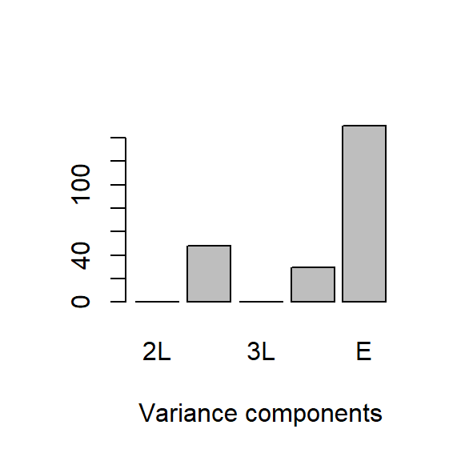

```r
barplot(as.vector(fitGF$theta), xlab = "Variance components",
  names.arg = c("2L", "2R", "3L", "3R", "E"))
```

The genomic variance is extremely small for chromosome arms 2L and 3L. Therefore these chromosome arms are excluded from the cross validation analysis.

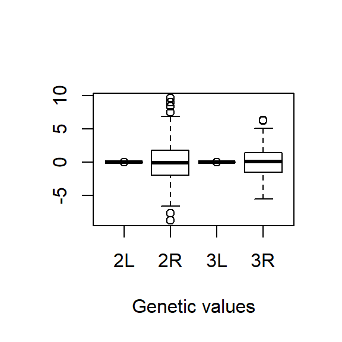

```r
boxplot(fitGF$g, xlab = "Genetic values", names = c("2L", "2R", "3L", "3R"))
```

#### **REML analyses and cross validation using the GFBLUP model**

The genomic parameters are estimated for the phenotypes from the lines in the training data ($t$,365 lines) and the phenotype is predicted for the lines in the validation data ($v$, 41 lines). The genetic value is predicted based on the genomic relationship between the training and validation population:
$$\mathbf{\hat{g}}_k^v = \hat\sigma_{g_k}^2 \mathbf{G}_{k}^{vt} \mathbf{Z}' \mathbf{\hat{V}_t}^{-1}(\mathbf{y}_t-\mathbf{X}_t\hat{\mathbf{b}}_t)$$
Where the genomic relationship matrix for the k^th feature
$$G_k =
\left(\begin{array}{cc} G_k^{vv} & G_k^{vt}
\\ G_k^{vt} & G_k^{tt} \end{array}
\right)$$

is partitioned according to relationships between the individuals in the training data $G_k^{tt}$, between the individuals in the validation data $G_k^{vv}$ and between the individuals in the training and validation data $G_k^{vt}$. Thus the total genomic predisposition is predicted using the estimated variance components ($\sigma_{g1}^2,...,\sigma_{n_f}^2$ and $\sigma_e^2$) in the training data. The right-most term, $(y_t-X_t\hat{b_t})$, constitutes the phenotypes corrected for fixed effects for the individuals in the training data. The inverse term $\hat{V}_t^{-1}$ is essentially the variance-covariance structure for the corrected phenotypes. These two terms multiplied together are the standardized and corrected phenotypes for the individuals in the training data, which are projected onto the total genetic covariance structure between the training and the validation data.

Based on the variance components estimated for the *training set*, the phenotype in the *validation set* is predicted as:
$$\hat{y_v} = X_v\hat{b_t} + \sum_{k=1}^{n_f}Z\hat{g}_k^v$$

5 validation sets are created by randomly sampling 41 values from 1 - 406 (the length of $\mathbf{y}$), and repeating this sampling 5 times. The validation sets are saved in the `validate` matrix. This matrix specifies the rows of the data to be used in the GREML analyses.

Since chrosomes 2L and 3L have variance components of 0, only chromosomes 2R and 3R are included as features for the prediction of $y$.

```r
n <- length(y)
validate <- replicate(5, sample(1:n, 41))
cvG <- greml(y = y, X = X, GRM = GF[c(2, 4)], validate = validate)
```

```r
str(cvG)
```

```r
library(knitr)
library(kableExtra)

kable(cvG$accuracy[1:5,], caption = "Cross Validation Predictive Ability") %>%
kable_styling(full_width = F, position = "left")
```

Cross Validation Predictive Ability

| Corr | R2 | Nagel R2 | AUC | intercept | slope | MSPE |
| --- | --- | --- | --- | --- | --- | --- |
| 0.158 | 0.025 | NA | NA | 52.058 | 0.035 | 251.535 |
| 0.304 | 0.092 | NA | NA | 49.093 | 0.066 | 188.048 |
| 0.169 | 0.028 | NA | NA | 49.911 | 0.062 | 146.678 |
| 0.173 | 0.030 | NA | NA | 49.070 | 0.064 | 185.663 |
| 0.076 | 0.006 | NA | NA | 52.656 | 0.022 | 175.750 |

```r
kable(cvG$theta[1:5,], caption = "Cross Validation Parameter Estimates") %>%
kable_styling(full_width = F, position = "left")
```

Cross Validation Parameter Estimates

| 2R | 3R | E |
| --- | --- | --- |
| 29.239 | 0.000 | 141.993 |
| 12.988 | 15.349 | 147.805 |
| 21.380 | 12.149 | 148.392 |
| 30.181 | 2.093 | 145.065 |
| 0.000 | 26.683 | 152.224 |

**Output of the GREML cross validation analysis**

The output includes statistics that quantify the model’s predictive ability as assessed by regressing the observed phenotype against the predicted phenotype for the validation data set: $y = intercept + \hat{y} slope + e$

Explanation of the values in `cvG$accuracy`:

| Value |  | Description |
| --- | --- | --- |
| Corr |  | Correlation between the predicted and observed phenotypic value. Averaging the list of 5 correlations yields the predictive ability |
| R2 |  | $R^2$, proportion of the total variance that is explained by the GFBLUP model |
| Nagel R2 |  | Nagelkerke’s $R$ |
| AUC |  | Area Under the ROC Curve |
| intercept |  | The y-axis intercept for the regression of $y$ unto $\hat{y}$ |
| slope |  | Slope for the regression of $y$ unto $\hat{y}$ |
| MSPE |  | mean squared prediction error = $\frac{1}{n_v}\sum_{i=1}^{n_v}({y_i - \hat{y_i})^2}$, $n_v$ = number of observations in validation set |

Explanation of the values in `cvG$theta`:

| Value |  | Description |
| --- | --- | --- |
| 2R |  | Estimated variance component, $\hat\sigma_{g_{2R}}^2$ |
| 3R |  | Estimated variance component, $\hat\sigma_{g_{3R}}^2$ |
| E |  | Estimated variance component, $\hat\sigma_{e}^2$ |

Prepare data frame of results.

```r
accuMeans <- colMeans(cvG$accuracy)
thetaMeans <- colMeans(cvG$theta)

accuSEM <- apply(cvG$accuracy, 2, function(x){sd(x)/sqrt(50)})
thetaSEM <- apply(cvG$theta, 2, function(x){sd(x)/sqrt(50)})

results1 <- round( rbind(accuMeans, accuSEM), digits=3)
results2 <- round( rbind(thetaMeans, thetaSEM), digits=3)
results <- cbind(c("mean","sem"),results1,results2)
rownames(results) <- NULL

kable(results, caption = "Results Summary")%>%
kable_styling(position = "left")
```

Results Summary

|  | Corr | R2 | Nagel R2 | AUC | intercept | slope | MSPE | 2R | 3R | E |
| --- | --- | --- | --- | --- | --- | --- | --- | --- | --- | --- |
| mean | 0.176 | 0.036 | NA | NA | 50.558 | 0.05 | 189.535 | 18.758 | 11.255 | 147.096 |
| sem | 0.012 | 0.005 | NA | NA | 0.239 | 0.003 | 5.426 | 1.778 | 1.527 | 0.541 |

**Genomic heritability ($\hat{h}^2$)**

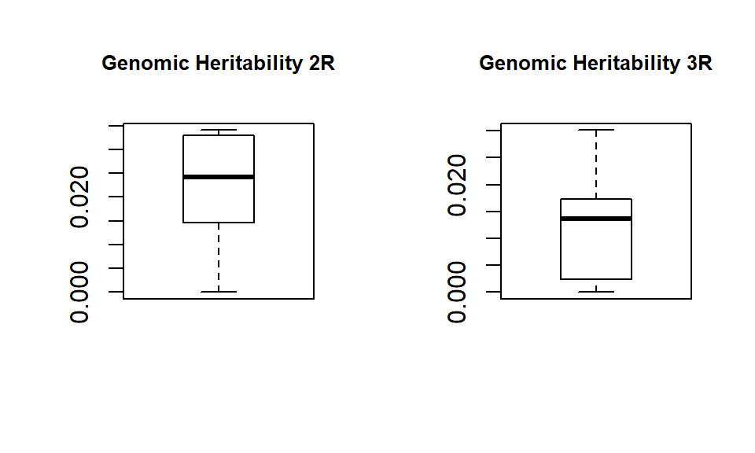

```r
theta <- cvG$theta
h2f2 <- theta["2R"]/sum(theta)
h2f4 <- theta["3R"]/sum(theta)

layout(matrix(1:2,ncol=2))
boxplot(h2f2, main = "Genomic Heritability 2R", cex.main=0.8)
boxplot(h2f4, main = "Genomic Heritability 3R", cex.main=0.8)
```

**Histogram of genetic values**

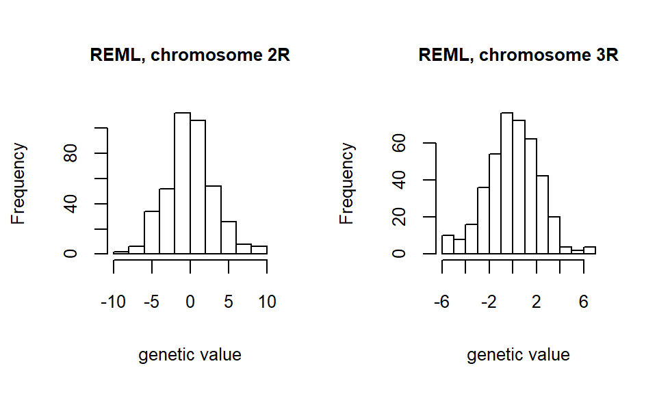

```r
layout(matrix(1:2,ncol=2))
hist(fitGF$g[,2], xlab = "genetic value", cex.lab=0.8, cex.axis=0.8,
     main = "REML, chromosome 2R", cex.main=0.8)
hist(fitGF$g[,4], xlab = "genetic value", cex.lab=0.8, cex.axis=0.8,
     main = "REML, chromosome 3R", cex.main=0.8)
```

**Histogram of phenotype**

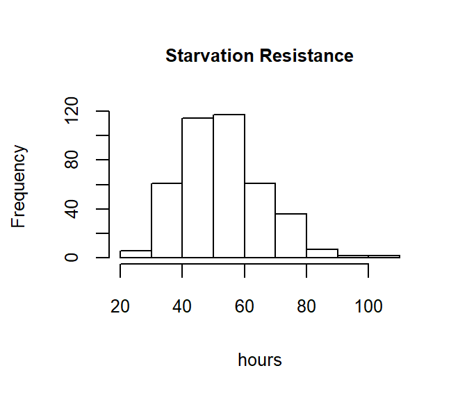

```r
hist(y, xlab = "hours", cex.lab=0.8, cex.axis=0.8, main = "Starvation Resistance", cex.main=0.8)
```